# U.S. Environment Insight

[figure not shown]

[figure not shown]

[figure not shown]

[figure not shown]

[figure not shown]

[figure not shown]

[figure not shown]

# Introduction & Abstract

### Abstract

*Page design authored by Xavier Akers*

Welcome to the 2024 U.S. Environment Insights Dashboard. We analyze the 2024 EPA Annual Concentration dataset to reveal important insights about the air quality in the United States. By examining pollutant measurements from monitoring sites around the country, we find trends in the data that are significant for public health and environmental policy. Our statistical methods predict the results of air quality and provide insight on the factors that affect them. This data-driven initiative aligns with EPA’s mission to protect the environment and achieve cleaner air for the public.

The data can be downloaded here [annual_conc_by_moinitor_2024.csv](https://drive.google.com/file/d/1VA5CdbeluNWSM6bxj-k1c8vU2GCBBbZi/view?usp=sharing) and is originally sourced from [EPA Pre-Generated Data File](https://aqs.epa.gov/aqsweb/airdata/download_files.html).

### Data Dictionary

| Variable | Description |
| --- | --- |
| State Code | State FIPS code |
| County Code | County FIPS code |
| Site Num | Monitoring site number |
| Parameter Code | Parameter code for pollutant |
| POC | Point of contact |
| Latitude | Latitude coordinate |
| Longitude | Longitude coordinate |
| Datum | Geodetic datum |
| Parameter Name | Pollutant name |
| Sample Duration | Sample duration |
| Pollutant Standard | Pollutant standard reference |
| Metric Used | Metric used for analysis |
| Method Name | Measurement method |
| Year | Year of data |
| Units of Measure | Units of measure |
| Event Type | Event type recorded |
| Observation Count | Number of valid observations |
| Observation Percent | Percent of valid observations |
| Completeness Indicator | Data completeness flag |
| Valid Day Count | Number of valid days |
| Required Day Count | Number of required days |
| Exceptional Data Count | Exceptional data count |
| Null Data Count | Null data count |
| Primary Exceedance Count | Primary standard exceedances |
| Secondary Exceedance Count | Secondary standard exceedances |
| Certification Indicator | Certification status |
| Num Obs Below MDL | Number of observations below detection limit |
| Arithmetic Mean | Arithmetic mean concentration |
| Arithmetic Standard Dev | Arithmetic standard deviation |
| 1st Max Value | Maximum observed value |
| 1st Max DateTime | Datetime of max value |
| 2nd Max Value | Second max value |
| 2nd Max DateTime | Datetime of second max |
| 3rd Max Value | Third max value |
| 3rd Max DateTime | Datetime of third max |
| 4th Max Value | Fourth max value |
| 4th Max DateTime | Datetime of fourth max |
| 1st Max Non Overlapping Value | First non-overlapping max |
| 1st NO Max DateTime | Datetime of first non-overlapping max |
| 2nd Max Non Overlapping Value | Second non-overlapping max |
| 2nd NO Max DateTime | Datetime of second non-overlapping max |
| 99th Percentile | 99th percentile |
| 98th Percentile | 98th percentile |
| 95th Percentile | 95th percentile |
| 90th Percentile | 90th percentile |
| 75th Percentile | 75th percentile |
| 50th Percentile | 50th percentile |
| 10th Percentile | 10th percentile |
| Local Site Name | Local site name |
| Address | Monitoring site address |
| State Name | State name |
| County Name | County name |
| City Name | City name |
| CBSA Name | Core-Based Statistical Area name |
| Date of Last Change | Date of last data change |

### Map of Monitoring Stations

[interactive chart not shown]

# Multiple Regression

### Multiple Linear Regression

**Research Question**: Can we predict the annual average concentration (Arithmetic Mean) of PM2.5 based on location and temporal variables?

**Modeling Approach**:  
- **Response Variable**: Arithmetic Mean  
- **Predictor Variables**: Latitude, Longitude, Year, Observation Count, 1st Max Value, 90th Percentile, 10th Percentile

**Justification**: This model aims to understand how geographical and temporal factors influence PM2.5 concentrations.

**Discussion**: Our multiple linear regression investigate whether annual average PM2.5 (Arithmetic Mean) can be predicted from coordinates, observation count, and pollutant measurement percentiles.

We find that all predictors except Year show statistically significant relationships with the response (< 0.005). This suggests that spatial coordinates, observation volumes, and percentile values can meaningfully predict the PM2.5 concentration.

**Interpretation** Northern locations tend to show lower PM2.5, while eastern location slightly increase it. This agrees with knowledge that many industries are established on the East Coast

More observations slightly reduce the average, perhaps that the lack of monitoring stations are inaccurately reflecting the true distribution.

**Limitations** We are assuming linearity, homoscedasticity, and no multicollinearity, which are unlikely to be true with the given data.

### Regression Results

Multiple Linear Regression Coefficients

| term | estimate | std.error | statistic | p.value |
| --- | --- | --- | --- | --- |
| (Intercept) | 3.6690 | 0.0791 | 46.4088 | 0 |
| Latitude | -0.0371 | 0.0014 | -27.1871 | 0 |
| Longitude | 0.0077 | 0.0004 | 17.2673 | 0 |
| Year | NA | NA | NA | NA |
| `Observation Count` | 0.0000 | 0.0000 | -5.8807 | 0 |
| `1st Max Value` | 0.0052 | 0.0002 | 24.1874 | 0 |
| `90th Percentile` | 0.3210 | 0.0021 | 152.3265 | 0 |
| `10th Percentile` | 0.4530 | 0.0067 | 67.2237 | 0 |

### Actual vs Predicted PM2.5

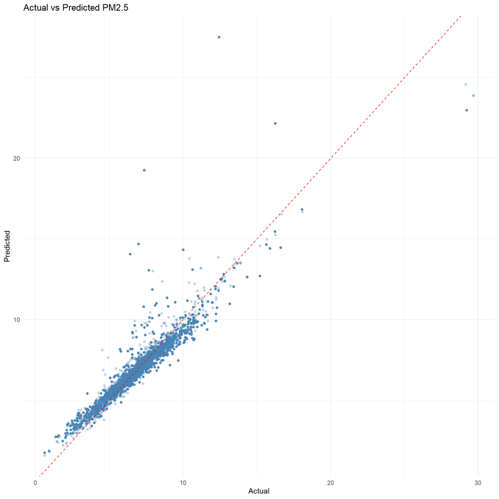

### Residuals vs Fitted

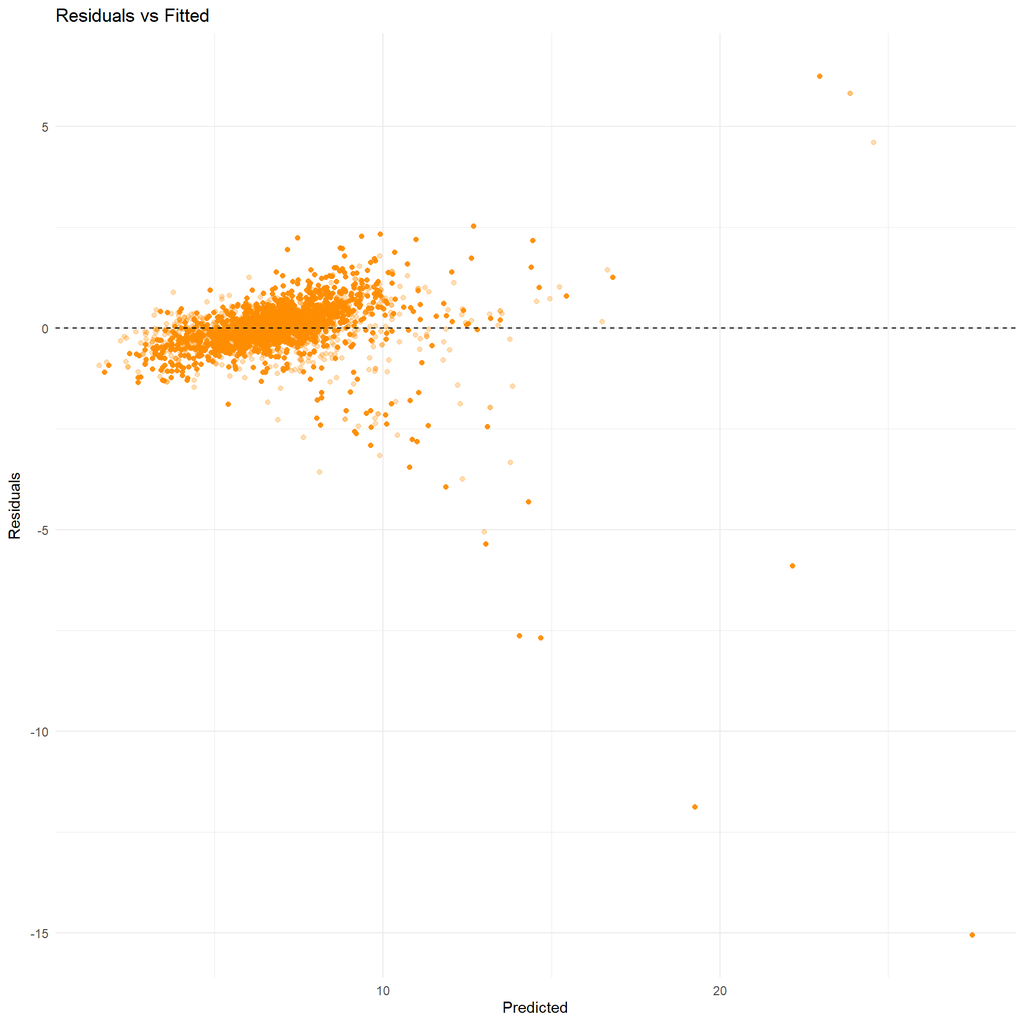

# Spatial Analysis

### Spatial Prediction of PM2.5 Concentrations

[interactive chart not shown]

# Ridge Regression

### Compute Model

```
**Number of Sites Before Join:**  7940
```

```
**Number of Sites After Join:**  1346
```

```
**Sites per State:**
```

```
State  04 :  24  sites
State  06 :  248  sites
State  08 :  40  sites
State  09 :  32  sites
State  12 :  8  sites
State  13 :  16  sites
State  15 :  8  sites
State  17 :  16  sites
State  18 :  71  sites
State  19 :  80  sites
State  20 :  8  sites
State  21 :  8  sites
State  22 :  8  sites
State  23 :  8  sites
State  24 :  80  sites
State  25 :  8  sites
State  26 :  80  sites
State  28 :  8  sites
State  29 :  100  sites
State  30 :  16  sites
State  31 :  8  sites
State  32 :  16  sites
State  33 :  16  sites
State  35 :  8  sites
State  37 :  16  sites
State  38 :  32  sites
State  39 :  24  sites
State  40 :  48  sites
State  41 :  40  sites
State  42 :  32  sites
State  44 :  24  sites
State  45 :  15  sites
State  47 :  8  sites
State  48 :  88  sites
State  51 :  16  sites
State  53 :  8  sites
State  54 :  8  sites
State  55 :  24  sites
State  56 :  48  sites
```

```
**Model Computed Successfully**
```

```
**Predictors Used:**
```

```
Outdoor Temperature, Relative Humidity, Wind Speed - Resultant, 1st Max Value, 90th Percentile
75th Percentile, 50th Percentile, Observation Count, Observation Percent, Latitude
Longitude, Year, Month
```

```
**Selected Lambda (Cross-Validation):**  0.2118
```

```
**Predicted PM2.5 Range:**  0.73  to  15.01  µg/m³
```

### Average Predicted PM2.5

6.65

### Number of Sites Analyzed

1346

### Data Coverage Period

2024

### 3D Visualization of PM2.5 Trends

[interactive chart not shown]

### Model Summary

*Analysis authored by Xavier Akers*

**Research Question**: Can Ridge Regression effectively predict PM2.5 concentrations by accounting for multicollinearity among meteorological factors (e.g., temperature, relative humidity, wind speed) and air quality metrics, and how do these factors interact spatially and temporally to influence PM2.5 levels across monitoring sites?

**Discussion**: Our Ridge Regression model examines whether PM2.5 (24 hour block average, *Arithmetic Mean*) can be predicted by spatial data, weather conditions, and air quality. This addresses the issues of multicollinearity from the MLR analysis.

**Interpretation**: Meteorological conditions and air quality metrics jointly determine the PM2.5 levels, but site-level, country-level, and state-level factors (linked to local emission sources and regulations) also influence the PM2.5 levels. This regularization ensured temperature, humidity, and percentiles do not dominate the model due to multicolilinearity.

#### Model Coefficients

Ridge Regression Coefficients (lambda = min)

| Predictor | Coefficient |
| --- | --- |
| (Intercept) | 1.5504 |
| `1st Max Value` | 0.0142 |
| `90th Percentile` | 0.1334 |
| `75th Percentile` | 0.1715 |
| `50th Percentile` | 0.2263 |
| `Observation Count` | 0.0000 |
| `Observation Percent` | 0.0028 |
| Latitude | -0.0139 |
| Longitude | 0.0053 |
| Year | 0.0000 |
| Month | 0.0135 |
| `State Code`04 | -0.3123 |
| `State Code`06 | -0.1783 |
| `State Code`08 | -0.1654 |
| `State Code`09 | -0.2796 |
| `State Code`12 | 0.0074 |
| `State Code`13 | 0.5514 |
| `State Code`15 | -1.5989 |
| `State Code`17 | 0.5127 |
| `State Code`18 | -0.0323 |
| `State Code`19 | 0.2901 |
| `State Code`20 | 0.2714 |
| `State Code`21 | -0.0095 |
| `State Code`22 | 1.4303 |
| `State Code`23 | -0.3425 |
| `State Code`24 | -0.2873 |
| `State Code`25 | -0.1988 |
| `State Code`26 | 0.0120 |
| `State Code`28 | 0.0615 |
| `State Code`29 | 0.0993 |

[output cut: 159 more lines]

### Actual vs Predicted PM2.5 (Ridge)

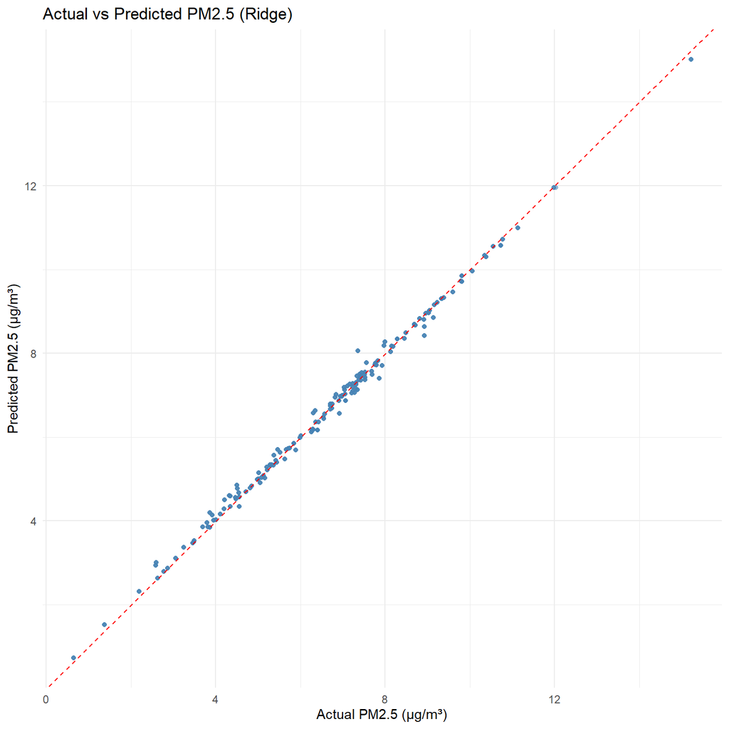

### Predictor Correlation Heatmap

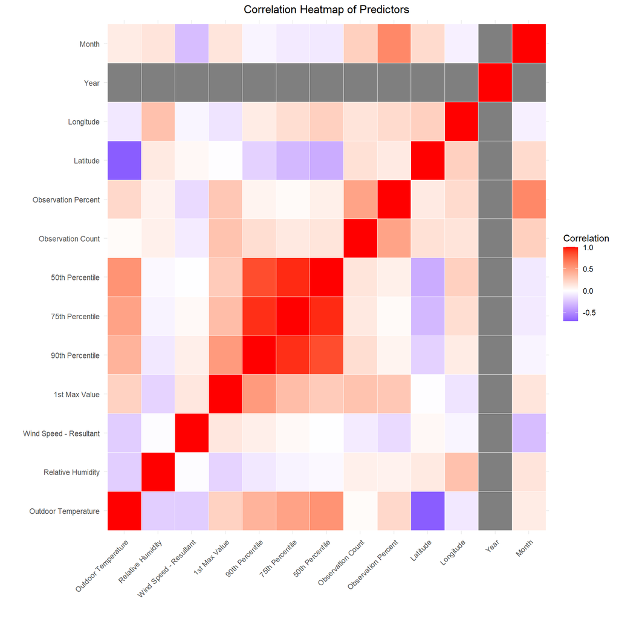

# LOESS Fit

### LOESS Fit for Seasonal PM2.5 Trends

*Analysis authored by Xavier Akers*

**Research Question**: How do seasonal variations in PM2.5 concentrations manifest at a specific monitoring site in 2024?

**Modeling Approach**:  
- **Response Variable**: Arithmetic Mean (PM2.5 concentration)  
- **Predictor Variable**: Month (derived from 1st Max DateTime)  
- **Method**: LOESS smoothing with span = 0.75.

**Justification**: LOESS captures non-linear seasonal patterns in air quality data.

**Variables in Final Model**:  
- **Arithmetic Mean**: PM2.5 concentration.  
- **Month**: Numeric value (1-12) from `1st Max DateTime`.

**Discussion**: Analyzing how seasonal patterns affect PM2.t concentrations at monitoring site in 2024, we see that PM2.5 concentrations fluctuate across months, reflecting known seasonal factors influencing pollutants. Since LOESS adapts to non-linear seasonal changes, we can see a clearer picture of when air quality deteriorates or improves throughout the year.

### LOESS Model Visualization

[interactive chart not shown]

### Summary Statistics

Summary Statistics for PM2.5 at Selected Site

| Metric | Value |
| --- | --- |
| Mean_PM2.5 | 6.47 |
| SD_PM2.5 | 1.98 |
| Min_PM2.5 | 3.67 |
| Max_PM2.5 | 14.36 |

### Distribution by Month

[interactive chart not shown]

# kNN Classification

### k-Nearest Neighbors Classification

**Research Question**: Can we classify monitoring sites as urban or rural based on air quality and spatial metrics in 2024?

**Modeling Approach**:  
- **Response Variable**: Site Type (Urban if in a Core-Based Statistical Area, else Rural)  
- **Predictor Variables**: Arithmetic Mean, 1st Max Value, 90th Percentile, Observation Count, Latitude, Longitude  
- **Method**: kNN classification with k optimized via cross-validation.

**Justification**: kNN classifies sites by leveraging similarities in air quality and spatial features, which differ between urban and rural areas.

**Variables in Final Model**:  
- **Site Type**: Binary response (Urban/Rural).  
- **Arithmetic Mean**, **1st Max Value**, **90th Percentile**, **Observation Count**, **Latitude**, **Longitude**: Predictors.

kNN Model Performance

| Metric | Value |
| --- | --- |
| Total Test Samples | 2633 |
| Overall Accuracy | 99.01% |
| Optimal k | 1 |

### Confusion Matrix

[interactive chart not shown]

### Distribution Plot

[interactive chart not shown]

# Naive Bayes

## Overview

*Page design and analysis authored by Xavier Akers*

- **Research Question:** Can we predict the pollutant type (`Parameter Name`) based on statistical features?
- **Modeling Approach:** Naive Bayes classifier, using predictors: Arithmetic Mean, 1st Max Value, 90th Percentile, Observation Count, etc.
- **Justification:** Naive Bayes is effective for multi-class classification with categorical outcomes.

### Top 10 Most Frequently Predicted Pollutant Types

| Predicted | n |
| --- | --- |
| PM2.5 - Local Conditions | 895 |
| Vanadium PM2.5 LC | 386 |
| SO2 max 5-min avg | 264 |
| Ozone | 244 |
| PM2.5 Raw Data | 238 |
| Nitrogen dioxide (NO2) | 217 |
| Magnesium PM2.5 LC | 196 |
| Bromochloromethane | 139 |
| Indium PM2.5 LC | 131 |
| Wind Direction - Resultant | 130 |

### Misclassification Table (Top Errors)

| Actual | Predicted | n |
| --- | --- | --- |
| PM2.5 - Local Conditions | PM2.5 Raw Data | 144 |
| Sulfur dioxide | SO2 max 5-min avg | 124 |
| Nitric oxide (NO) | SO2 max 5-min avg | 51 |
| PM10 - LC | PM2.5 Raw Data | 39 |
| OP PM2.5 LC TOR | OC4 PM2.5 LC | 34 |
| Outdoor Temperature | Dew Point | 34 |

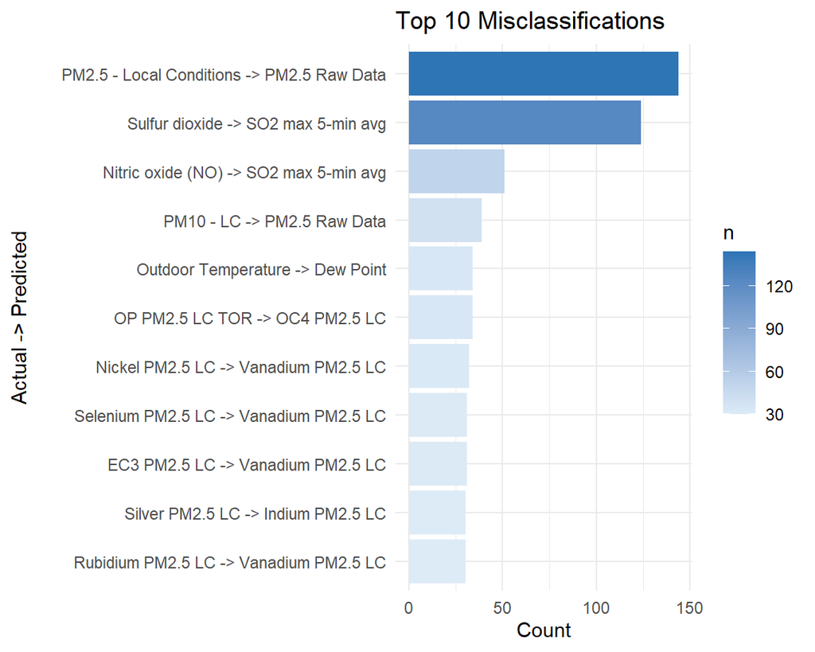

# Logistic Regression

## Overview

*Page design and analysis authored by Xavier Akers*

- **Research Question:** What factors influence the likelihood of exceeding primary pollutant standards?
- **Modeling Approach:**
  - **Response Variable:** Exceedance (binary: 1 if `Primary Exceedance Count` > 0, else 0)
  - **Predictor Variables:** Arithmetic Mean, 1st Max Value, Observation Count, Parameter Name (encoded)
- **Justification:** Logistic regression models the probability of a binary outcome based on predictor variables.

Logistic Regression Model Performance

| Metric | Value |
| --- | --- |
| Total Test Samples | 2784 |
| Overall Accuracy | 83.8% |

### Coefficient Summary

Logistic Regression Coefficients

| term | estimate | std.error | statistic | p.value |
| --- | --- | --- | --- | --- |
| (Intercept) | -17.9376127 | 207.6445667 | -0.0863861 | 0.9311595 |
| `Arithmetic Mean` | -0.0587339 | 0.0203965 | -2.8796088 | 0.0039817 |
| `1st Max Value` | 0.1369915 | 0.0045238 | 30.2823482 | 0.0000000 |
| `Observation Count` | 0.0000315 | 0.0000045 | 7.0402162 | 0.0000000 |
| `Parameter Name`Lead (TSP) LC | 0.3566681 | 433.6186318 | 0.0008225 | 0.9993437 |
| `Parameter Name`Nitrogen dioxide (NO2) | 3.1373286 | 207.6566497 | 0.0151083 | 0.9879458 |
| `Parameter Name`Ozone | 16.2675020 | 207.6445687 | 0.0783430 | 0.9375552 |
| `Parameter Name`PM10 Total 0-10um STP | -1.8284065 | 207.6460411 | -0.0088054 | 0.9929744 |
| `Parameter Name`PM2.5 - Local Conditions | 13.9403721 | 207.6446168 | 0.0671357 | 0.9464737 |
| `Parameter Name`Sulfur dioxide | 6.9164161 | 207.6455055 | 0.0333088 | 0.9734284 |

### Discussion

The logistic regression model achieved an overall accuracy of **83.8%** in predicting whether a site exceed primary pollutant standards. Observation Count showed significant positive effects on exceedance likelihood. However, most pollutant parameter categories (ozone, PM2.5, NO_2) had non-significant coefficients and were not meaningful to differentiate exceedance in this model. The results show that short-team peak pollution levels and observation intensity are the key features of exceedance risk.

## Visuals

### Coefficients

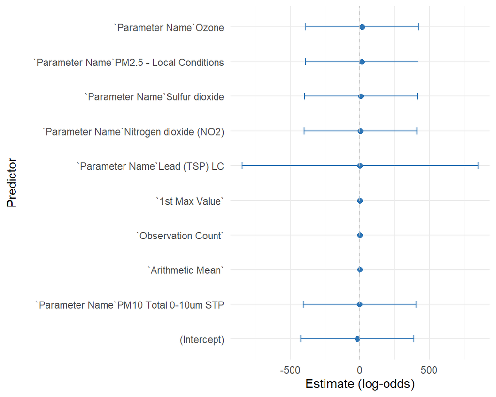

### Probalities vs Arithmetic Mean

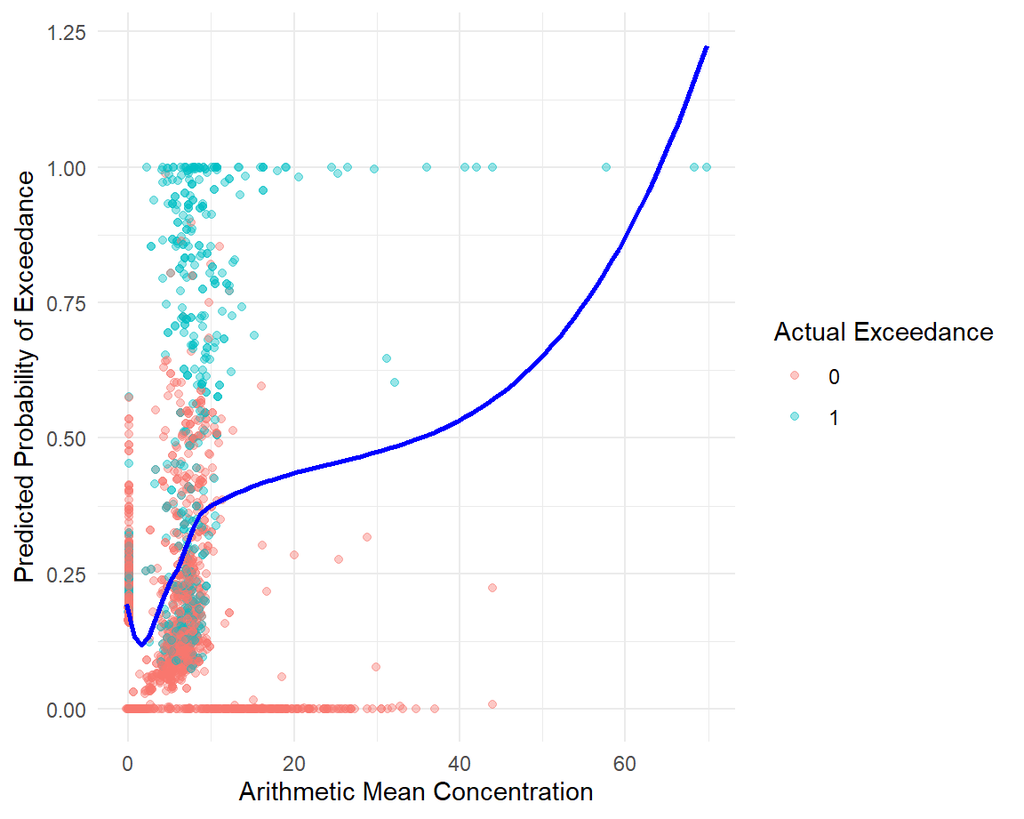